# Sonali’s Norway Spruce light experiment Biological QA

Sonali Ranade and Nicolas Delhomme

2015-12-09

# 1 Setup

Set the working dir

```r
setwd("/mnt/picea/projects/spruce/rgarcia/light")
```

Load libraries

```r
suppressPackageStartupMessages(library(DESeq2))
suppressPackageStartupMessages(library(gplots))
suppressPackageStartupMessages(library(parallel))
suppressPackageStartupMessages(library(pander))
suppressPackageStartupMessages(library(RColorBrewer))
suppressPackageStartupMessages(library(scatterplot3d))
suppressPackageStartupMessages(library(vsn))
```

Source some helper functions

```r
source("~/Git/UPSCb/src/R/plot.multidensity.R")
```

Create a palette

```r
pal <- brewer.pal(8,"Dark2")
```

Register the default plot margin

```r
mar <- par("mar")
```

Read the sample information

```r
samples <- read.csv("~/Git/UPSCb/projects/spruce-pine-light/doc/samples.csv")
```

Read the HTSeq files in a matrix

```r
res <- mclapply(dir("htseq",pattern="*.txt",full.names=TRUE),function(fil){
  read.delim(fil,header=FALSE,stringsAsFactors=FALSE)
},mc.cores=max(mcaffinity()))

names(res) <- sub(".*_P2254","P2254",sub("_sortmerna.*\\.txt","",dir("htseq",pattern="*.txt")))
```

Reorder the sample data.frame according to the way the results were read in and accounting for tech reps

```r
samples <- samples[match(names(res),samples$SampleName),]
samples$SampleDescription <- factor(as.character(samples$SampleDescription))
samples$SampleName <- factor(as.character(samples$SampleName))
```

Raw Data QC analysis

```r
addInfo <- c("__no_feature","__ambiguous","__too_low_aQual","__not_aligned","__alignment_not_unique")
sel <- match(addInfo,res[[1]][,1])
count.table <- do.call(cbind,lapply(res,"[",3))[-sel,]
colnames(count.table) <- names(res)
rownames(count.table) <- res[[1]][,1][-sel]
dir.create(file.path("analysis","HTSeq"),recursive = TRUE, showWarnings = FALSE)
write.csv(count.table,"analysis/HTSeq/raw-unormalised-data.csv")
```

Extract the HTSeq stat lines

```r
count.stats <- do.call(cbind,lapply(res,"[",2))[sel,]
colnames(count.stats) <- names(res)
rownames(count.stats) <- sub("__","",addInfo)
count.stats <- rbind(count.stats,aligned=colSums(count.table))
count.stats <- count.stats[rowSums(count.stats) > 0,]
```

Convert them into percentages

```r
pander(apply(count.stats,2,function(co){round(co*100/sum(co))}))
```

Table continues below

|  | P2254_138 | P2254_146 | P2254_148 | P2254_159 |
| --- | --- | --- | --- | --- |
| **no_feature** | 16 | 17 | 18 | 18 |
| **alignment_not_unique** | 10 | 9 | 9 | 8 |
| **aligned** | 74 | 74 | 73 | 74 |

Table continues below

|  | P2254_160 | P2254_161 | P2254_162 | P2254_163 |
| --- | --- | --- | --- | --- |
| **no_feature** | 19 | 19 | 19 | 19 |
| **alignment_not_unique** | 8 | 9 | 9 | 9 |
| **aligned** | 73 | 72 | 73 | 73 |

Table continues below

|  | P2254_170 | P2254_171 | P2254_138 | P2254_146 |
| --- | --- | --- | --- | --- |
| **no_feature** | 19 | 19 | 16 | 17 |
| **alignment_not_unique** | 8 | 9 | 10 | 9 |
| **aligned** | 72 | 72 | 74 | 74 |

Table continues below

|  | P2254_148 | P2254_159 | P2254_160 | P2254_161 |
| --- | --- | --- | --- | --- |
| **no_feature** | 18 | 18 | 19 | 19 |
| **alignment_not_unique** | 9 | 8 | 8 | 9 |
| **aligned** | 73 | 74 | 73 | 72 |

Table continues below

|  | P2254_162 | P2254_163 | P2254_170 | P2254_171 |
| --- | --- | --- | --- | --- |
| **no_feature** | 19 | 19 | 19 | 19 |
| **alignment_not_unique** | 9 | 9 | 8 | 9 |
| **aligned** | 73 | 73 | 72 | 72 |

Table continues below

|  | P2254_138 | P2254_146 | P2254_148 | P2254_159 |
| --- | --- | --- | --- | --- |
| **no_feature** | 16 | 17 | 18 | 18 |
| **alignment_not_unique** | 10 | 9 | 9 | 8 |
| **aligned** | 74 | 74 | 73 | 74 |

Table continues below

|  | P2254_160 | P2254_161 | P2254_162 | P2254_163 |
| --- | --- | --- | --- | --- |
| **no_feature** | 19 | 19 | 19 | 19 |
| **alignment_not_unique** | 8 | 9 | 9 | 9 |
| **aligned** | 73 | 72 | 73 | 73 |

Table continues below

|  | P2254_170 | P2254_171 | P2254_138 | P2254_146 |
| --- | --- | --- | --- | --- |
| **no_feature** | 19 | 19 | 16 | 17 |
| **alignment_not_unique** | 8 | 9 | 10 | 9 |
| **aligned** | 72 | 72 | 74 | 74 |

Table continues below

|  | P2254_148 | P2254_159 | P2254_160 | P2254_161 |
| --- | --- | --- | --- | --- |
| **no_feature** | 18 | 18 | 19 | 19 |
| **alignment_not_unique** | 9 | 8 | 8 | 9 |
| **aligned** | 73 | 74 | 73 | 72 |

Table continues below

|  | P2254_162 | P2254_163 | P2254_170 | P2254_171 |
| --- | --- | --- | --- | --- |
| **no_feature** | 19 | 19 | 19 | 19 |
| **alignment_not_unique** | 9 | 9 | 8 | 9 |
| **aligned** | 73 | 73 | 72 | 72 |

Table continues below

|  | P2254_138 | P2254_146 | P2254_148 | P2254_159 |
| --- | --- | --- | --- | --- |
| **no_feature** | 16 | 17 | 18 | 18 |
| **alignment_not_unique** | 10 | 9 | 9 | 8 |
| **aligned** | 74 | 74 | 73 | 74 |

Table continues below

|  | P2254_160 | P2254_161 | P2254_162 | P2254_163 |
| --- | --- | --- | --- | --- |
| **no_feature** | 19 | 19 | 19 | 19 |
| **alignment_not_unique** | 8 | 9 | 9 | 9 |
| **aligned** | 73 | 72 | 73 | 73 |

Table continues below

|  | P2254_170 | P2254_171 | P2254_138 | P2254_146 |
| --- | --- | --- | --- | --- |
| **no_feature** | 19 | 19 | 16 | 17 |
| **alignment_not_unique** | 8 | 9 | 10 | 9 |
| **aligned** | 72 | 72 | 74 | 74 |

Table continues below

|  | P2254_148 | P2254_159 | P2254_160 | P2254_161 |
| --- | --- | --- | --- | --- |
| **no_feature** | 18 | 18 | 19 | 19 |
| **alignment_not_unique** | 9 | 8 | 8 | 9 |
| **aligned** | 73 | 74 | 73 | 72 |

Table continues below

|  | P2254_162 | P2254_163 | P2254_170 | P2254_171 |
| --- | --- | --- | --- | --- |
| **no_feature** | 19 | 19 | 19 | 19 |
| **alignment_not_unique** | 9 | 9 | 8 | 9 |
| **aligned** | 73 | 73 | 72 | 72 |

Table continues below

|  | P2254_138 | P2254_146 | P2254_148 | P2254_159 |
| --- | --- | --- | --- | --- |
| **no_feature** | 16 | 17 | 18 | 18 |
| **alignment_not_unique** | 10 | 9 | 9 | 8 |
| **aligned** | 74 | 74 | 73 | 74 |

Table continues below

|  | P2254_160 | P2254_161 | P2254_162 | P2254_163 |
| --- | --- | --- | --- | --- |
| **no_feature** | 19 | 19 | 19 | 19 |
| **alignment_not_unique** | 8 | 9 | 9 | 9 |
| **aligned** | 73 | 72 | 73 | 73 |

Table continues below

|  | P2254_170 | P2254_171 | P2254_138 | P2254_146 |
| --- | --- | --- | --- | --- |
| **no_feature** | 19 | 19 | 16 | 17 |
| **alignment_not_unique** | 8 | 9 | 10 | 9 |
| **aligned** | 72 | 72 | 74 | 74 |

Table continues below

|  | P2254_148 | P2254_159 | P2254_160 | P2254_161 |
| --- | --- | --- | --- | --- |
| **no_feature** | 18 | 18 | 19 | 19 |
| **alignment_not_unique** | 9 | 8 | 8 | 9 |
| **aligned** | 73 | 74 | 73 | 72 |

|  | P2254_162 | P2254_163 | P2254_170 | P2254_171 |
| --- | --- | --- | --- | --- |
| **no_feature** | 19 | 19 | 19 | 19 |
| **alignment_not_unique** | 9 | 9 | 8 | 9 |
| **aligned** | 73 | 73 | 72 | 72 |

Plot the stats

There are no outliers

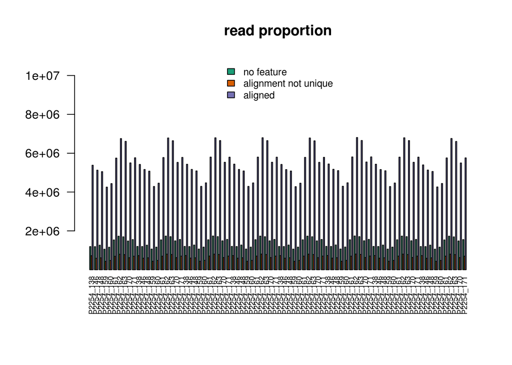

```r
col <- pal[1:nrow(count.stats)]
par(mar=c(7.1,5.1,4.1,2.1))
barplot(as.matrix(count.stats),col=col,beside=TRUE,las=2,main="read proportion",
        ylim=range(count.stats) + c(0,4e+6),cex.names=.6)
legend("top",fill=col,legend=gsub("_"," ",rownames(count.stats)),bty="n",cex=0.8)
```

```r
par(mar=mar)
```

The average percentage of aligned reads is 73%

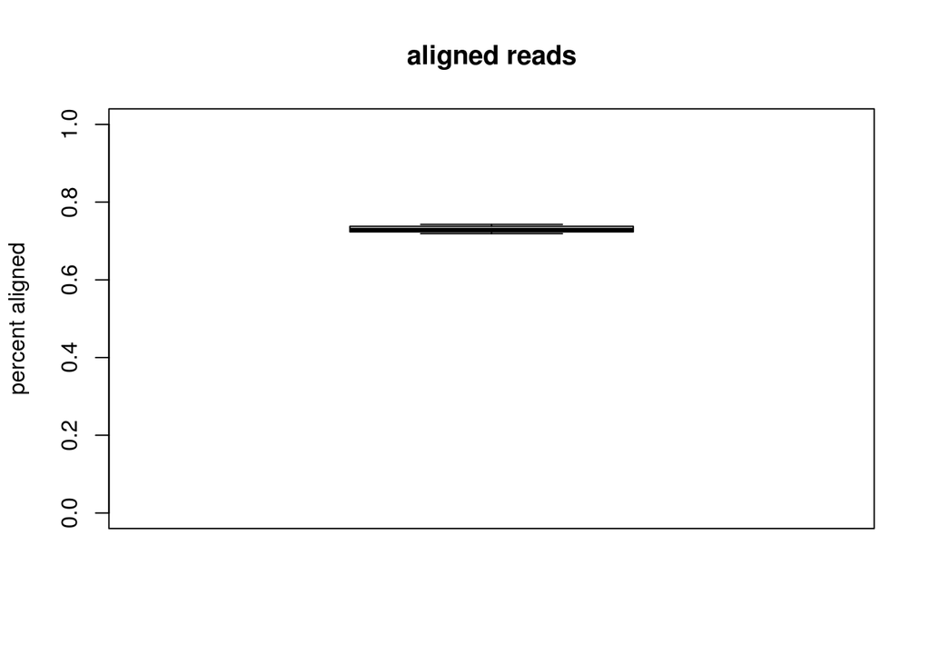

```r
# round(mean(unlist(count.stats["aligned",]/colSums(count.stats))),digits=2)*100
boxplot(unlist(count.stats["aligned",]/colSums(count.stats)),
        main="aligned reads",ylab="percent aligned",ylim=c(0,1))
```

Check how many genes are never expressed

```r
sel <- rowSums(count.table) == 0
sprintf("%s%% percent (%s) of %s genes are not expressed",
        round(sum(sel) * 100/ nrow(count.table),digits=1),
        sum(sel),
        nrow(count.table))
```

```
## [1] "28.1% percent (19872) of 70736 genes are not expressed"
```

Display the per-gene mean expression

i.e. the mean raw count of every gene across samples is calculated and displayed on a log10 scale.

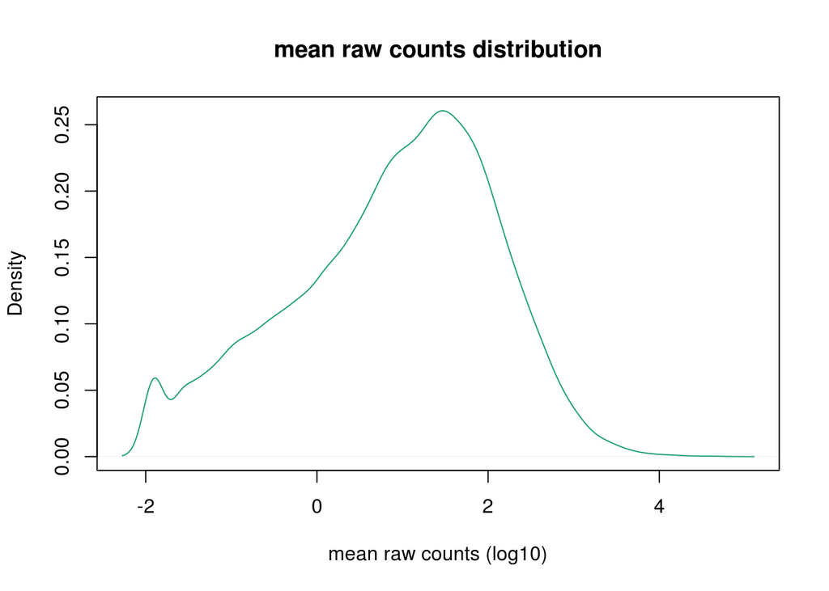

```r
plot(density(log10(rowMeans(count.table))),col=pal[1],
     main="mean raw counts distribution",
     xlab="mean raw counts (log10)")
```

The same is done for the individual samples colored by sample type

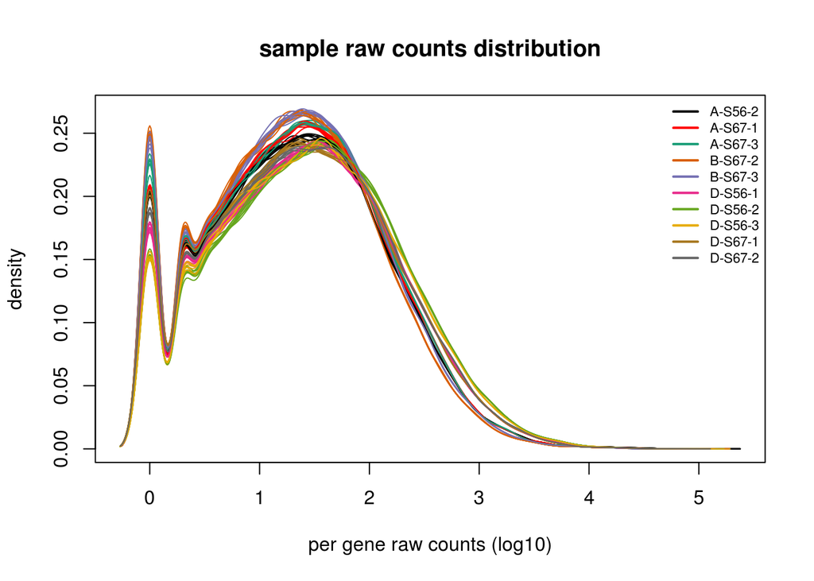

```r
plot.multidensity(log10(count.table),
                  col=c(1,2,pal)[as.integer(samples$SampleDescription)],
                  legend.x="topright",
                  legend=levels(samples$SampleDescription),
                  legend.col=c(1,2,pal),
                  legend.lwd=2,legend.cex = 0.7,
                  main="sample raw counts distribution",
                  xlab="per gene raw counts (log10)")
```

# 2 Data normalisation

For visualization, the data is submitted to a variance stabilization transformation using DESeq2. The dispersion is estimated independently of the sample tissue and replicate Create the dds object

```r
conditions <- colnames(count.table)
dds <- DESeqDataSetFromMatrix(
  countData = count.table,
  colData = data.frame(condition=conditions),
  design = ~ condition)
```

Check the size factors (i.e. the sequencing library size effect) There is no big variation, a Variance Stabilizing Transformation can be used (over a Relative Log Transformation)

```r
dds <- estimateSizeFactors(dds)
sizes <- sizeFactors(dds)
names(sizes) <- colnames(count.table)
pander(sizes)
```

Table continues below

| P2254_138 | P2254_146 | P2254_148 | P2254_159 | P2254_160 | P2254_161 |
| --- | --- | --- | --- | --- | --- |
| 0.8687 | 0.9154 | 0.9314 | 0.8231 | 0.9119 | 1.105 |

Table continues below

| P2254_162 | P2254_163 | P2254_170 | P2254_171 | P2254_138 | P2254_146 |
| --- | --- | --- | --- | --- | --- |
| 1.306 | 1.217 | 1.058 | 1.127 | 0.8757 | 0.9225 |

Table continues below

| P2254_148 | P2254_159 | P2254_160 | P2254_161 | P2254_162 | P2254_163 |
| --- | --- | --- | --- | --- | --- |
| 0.9369 | 0.826 | 0.9133 | 1.108 | 1.307 | 1.222 |

Table continues below

| P2254_170 | P2254_171 | P2254_138 | P2254_146 | P2254_148 | P2254_159 |
| --- | --- | --- | --- | --- | --- |
| 1.064 | 1.129 | 0.8754 | 0.9231 | 0.938 | 0.829 |

Table continues below

| P2254_160 | P2254_161 | P2254_162 | P2254_163 | P2254_170 | P2254_171 |
| --- | --- | --- | --- | --- | --- |
| 0.9189 | 1.112 | 1.31 | 1.22 | 1.066 | 1.131 |

Table continues below

| P2254_138 | P2254_146 | P2254_148 | P2254_159 | P2254_160 | P2254_161 |
| --- | --- | --- | --- | --- | --- |
| 0.8735 | 0.9222 | 0.9377 | 0.8291 | 0.9156 | 1.112 |

Table continues below

| P2254_162 | P2254_163 | P2254_170 | P2254_171 | P2254_138 | P2254_146 |
| --- | --- | --- | --- | --- | --- |
| 1.31 | 1.222 | 1.065 | 1.133 | 0.8761 | 0.9228 |

Table continues below

| P2254_148 | P2254_159 | P2254_160 | P2254_161 | P2254_162 | P2254_163 |
| --- | --- | --- | --- | --- | --- |
| 0.9366 | 0.8299 | 0.9171 | 1.109 | 1.309 | 1.218 |

Table continues below

| P2254_170 | P2254_171 | P2254_138 | P2254_146 | P2254_148 | P2254_159 |
| --- | --- | --- | --- | --- | --- |
| 1.064 | 1.132 | 0.8781 | 0.9248 | 0.941 | 0.8309 |

Table continues below

| P2254_160 | P2254_161 | P2254_162 | P2254_163 | P2254_170 | P2254_171 |
| --- | --- | --- | --- | --- | --- |
| 0.9198 | 1.115 | 1.312 | 1.222 | 1.067 | 1.133 |

Table continues below

| P2254_138 | P2254_146 | P2254_148 | P2254_159 | P2254_160 | P2254_161 |
| --- | --- | --- | --- | --- | --- |
| 0.8782 | 0.9221 | 0.9406 | 0.8282 | 0.9187 | 1.111 |

Table continues below

| P2254_162 | P2254_163 | P2254_170 | P2254_171 | P2254_138 | P2254_146 |
| --- | --- | --- | --- | --- | --- |
| 1.314 | 1.223 | 1.063 | 1.132 | 0.8705 | 0.9192 |

Table continues below

| P2254_148 | P2254_159 | P2254_160 | P2254_161 | P2254_162 | P2254_163 |
| --- | --- | --- | --- | --- | --- |
| 0.9345 | 0.8227 | 0.9131 | 1.102 | 1.304 | 1.213 |

| P2254_170 | P2254_171 |
| --- | --- |
| 1.061 | 1.123 |

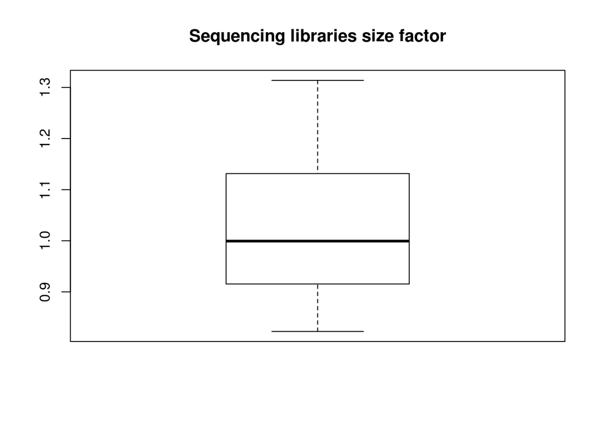

```r
boxplot(sizes, main="Sequencing libraries size factor")
```

Perform the VST

```r
colData(dds)$condition <- factor(colData(dds)$condition,
                                 levels=unique(conditions))
vsd <- varianceStabilizingTransformation(dds, blind=TRUE)
vst <- assay(vsd)
colnames(vst) <- colnames(count.table)
vst <- vst - min(vst)
write.csv(vst,"analysis/HTSeq/library-size-normalized_variance-stabilized_data.csv")
```

Validate the VST

Visualize the corrected mean - sd relationship. It is fairly linear, meaning we can assume homoscedasticity. The slight initial trend / bump is due to genes having few counts in a few subset of the samples and hence having a higher variability. This is expected.

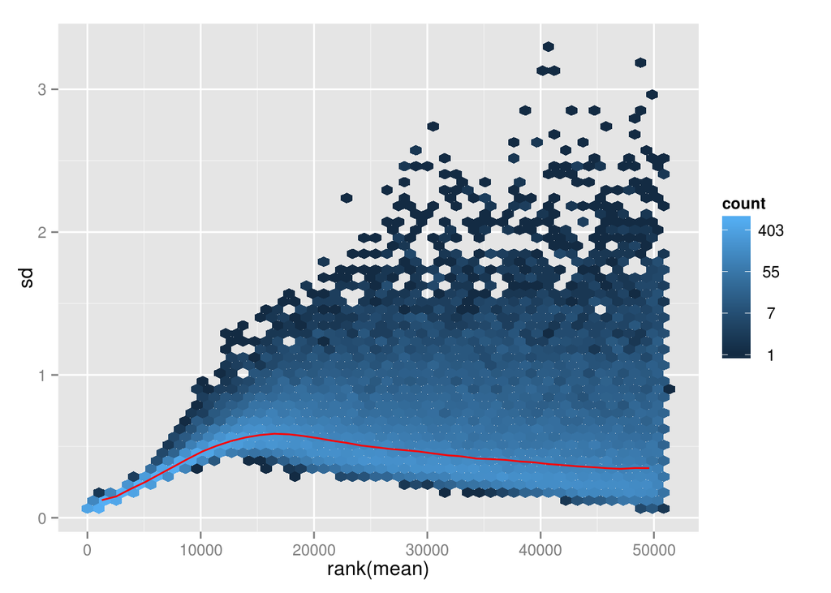

```r
meanSdPlot(vst[rowSums(count.table)>0,], ylim = c(0,2.5))
```

# 3 QC on the normalised data

## 3.1 PCA

First perform a Principal Component Analysis (PCA) of the data to do a quick quality assessment; i.e. replicate should cluster and the first 2-3 dimensions shouldbe explainable by biological means.

```r
pc <- prcomp(t(vst))
percent <- round(summary(pc)$importance[2,]*100)
```

Plot the PCA 3 first dimensions

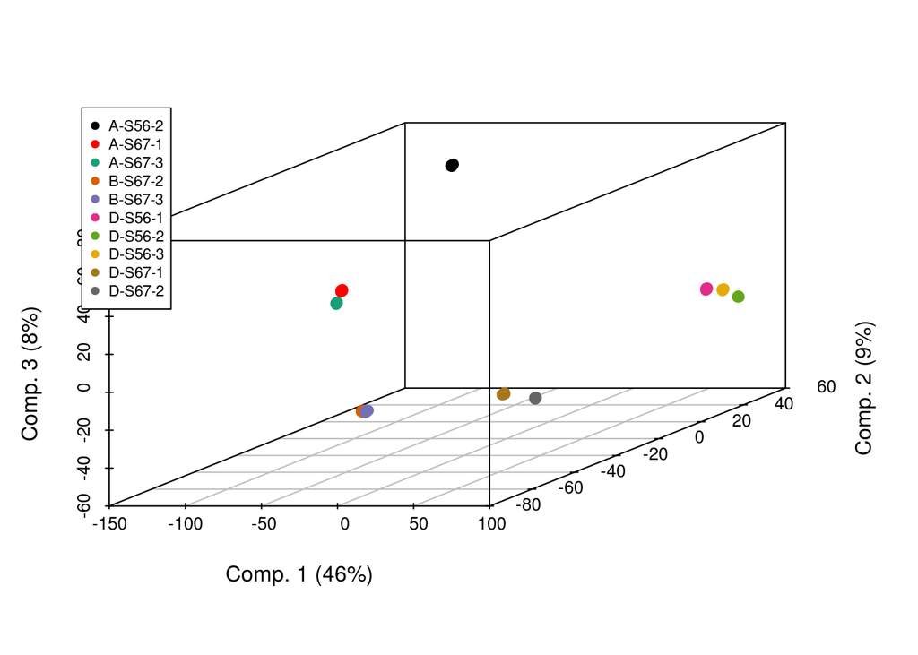

```r
mar=c(5.1,4.1,4.1,2.1)
scatterplot3d(pc$x[,1],
              pc$x[,2],
              pc$x[,3],
              xlab=paste("Comp. 1 (",percent[1],"%)",sep=""),
              ylab=paste("Comp. 2 (",percent[2],"%)",sep=""),
              zlab=paste("Comp. 3 (",percent[3],"%)",sep=""),
              color=c(1,2,pal)[as.integer(samples$SampleDescription)],
              pch=19)
legend("topleft",pch=19,
       col=c(1,2,pal)[as.integer(samples$SampleDescription)],
       legend=levels(samples$SampleDescription),cex=0.7)
```

```r
par(mar=mar)
```

Then the first two dimensions The first dimension separates the light conditions (Dark, A & B). The second dimension shows  
variability within the two ecotypes

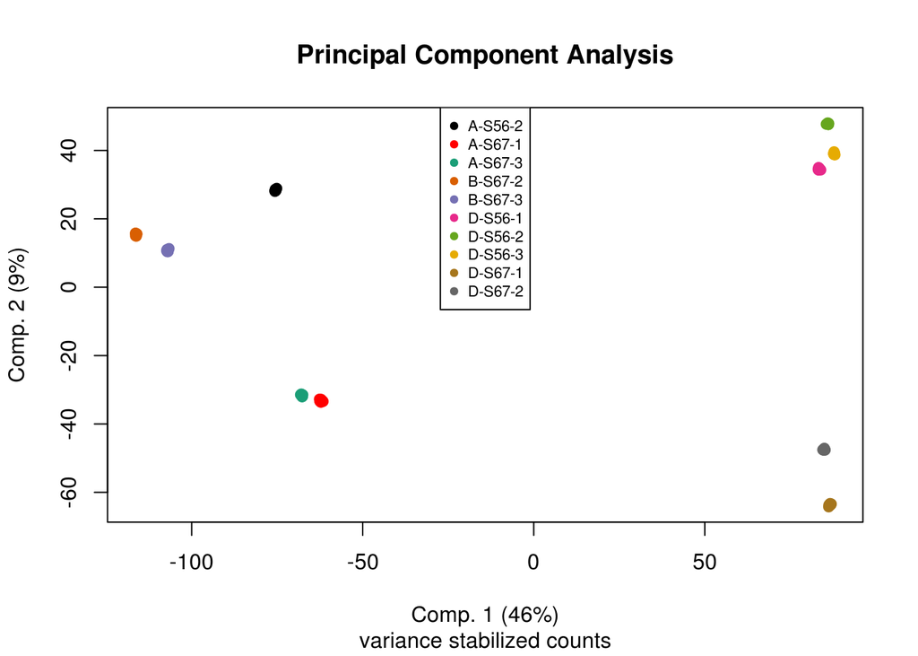

```r
plot(pc$x[,1],
     pc$x[,2],
     xlab=paste("Comp. 1 (",percent[1],"%)",sep=""),
     ylab=paste("Comp. 2 (",percent[2],"%)",sep=""),
     col=c(1,2,pal)[as.integer(samples$SampleDescription)],
     pch=19,
     main="Principal Component Analysis",sub="variance stabilized counts")
legend("top",pch=19,
       col=c(1,2,pal)[as.integer(samples$SampleDescription)],
       legend=levels(samples$SampleDescription),cex=0.7)
```

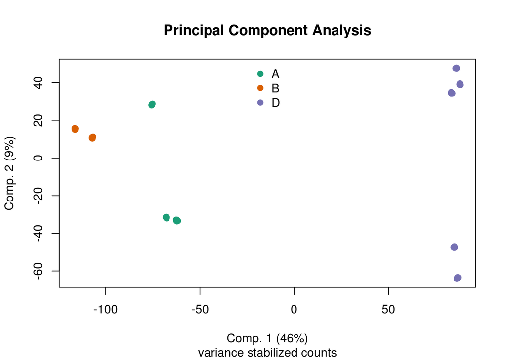

```r
plot(pc$x[,1],
     pc$x[,2],
     xlab=paste("Comp. 1 (",percent[1],"%)",sep=""),
     ylab=paste("Comp. 2 (",percent[2],"%)",sep=""),
     col=c(pal[1:3])[as.integer(factor(substr(samples$SampleDescription,1,1)))],
     pch=19,
     main="Principal Component Analysis",sub="variance stabilized counts")
legend("top",col=pal[1:3],
       legend=levels(factor(substr(samples$SampleDescription,1,1))),
       pch=19,bty="n")
```

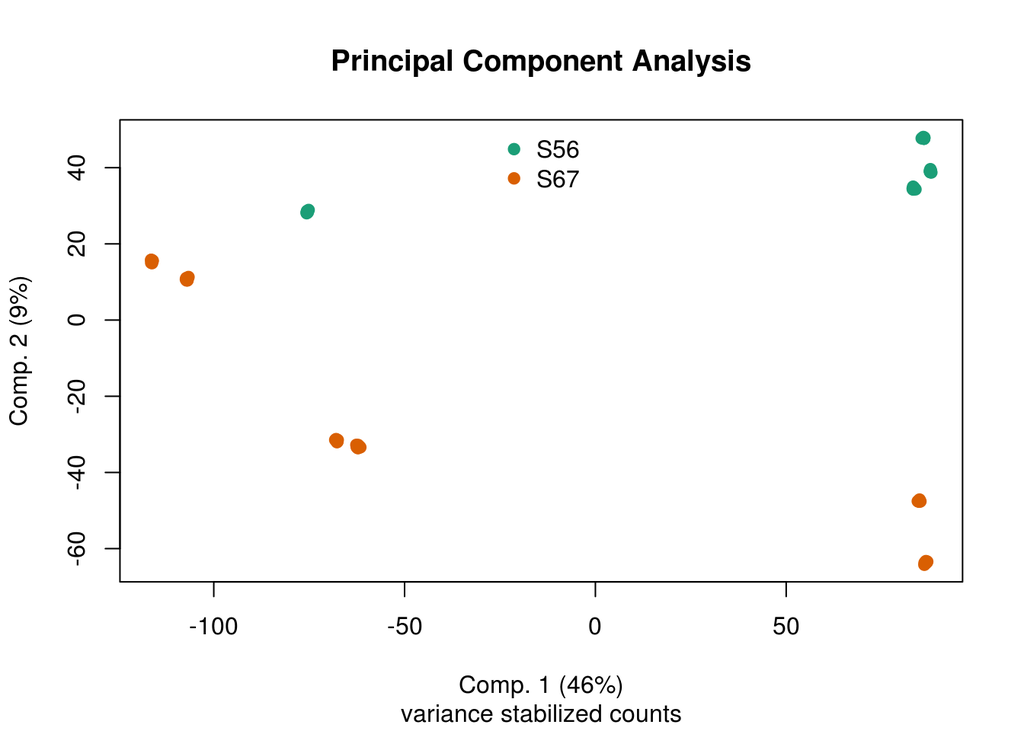

```r
plot(pc$x[,1],
     pc$x[,2],
     xlab=paste("Comp. 1 (",percent[1],"%)",sep=""),
     ylab=paste("Comp. 2 (",percent[2],"%)",sep=""),
     col=c(pal[1:2])[as.integer(factor(substr(samples$SampleDescription,3,5)))],
     pch=19,
     main="Principal Component Analysis",sub="variance stabilized counts")
legend("top",col=pal[1:2],
       legend=levels(factor(substr(samples$SampleDescription,3,5))),
       pch=19,bty="n")
```

And the 2nd and 3rd dims

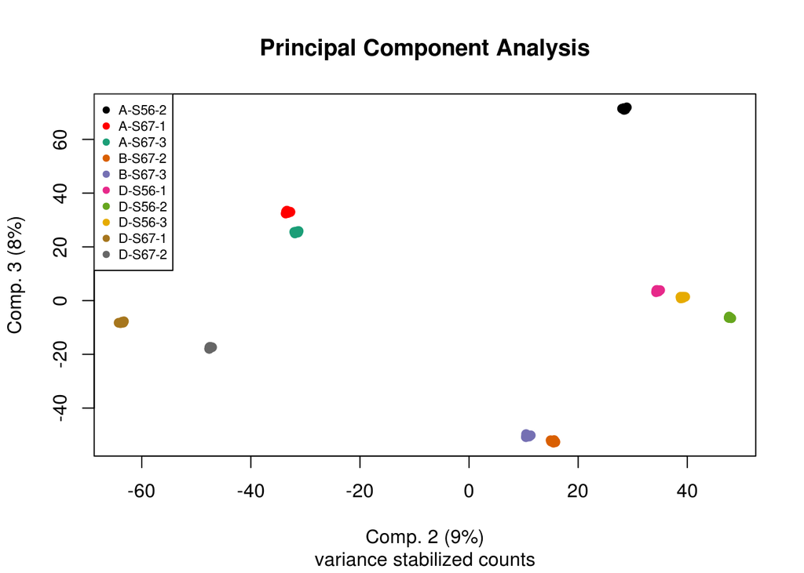

```r
plot(pc$x[,2],
     pc$x[,3],
     xlab=paste("Comp. 2 (",percent[2],"%)",sep=""),
     ylab=paste("Comp. 3 (",percent[3],"%)",sep=""),
     col=c(1,2,pal)[as.integer(factor(samples$SampleDescription))],
     pch=19,
     main="Principal Component Analysis",sub="variance stabilized counts")
legend("topleft",pch=19,
       col=c(1,2,pal)[as.integer(samples$SampleDescription)],
       legend=levels(samples$SampleDescription),cex=0.7)
```

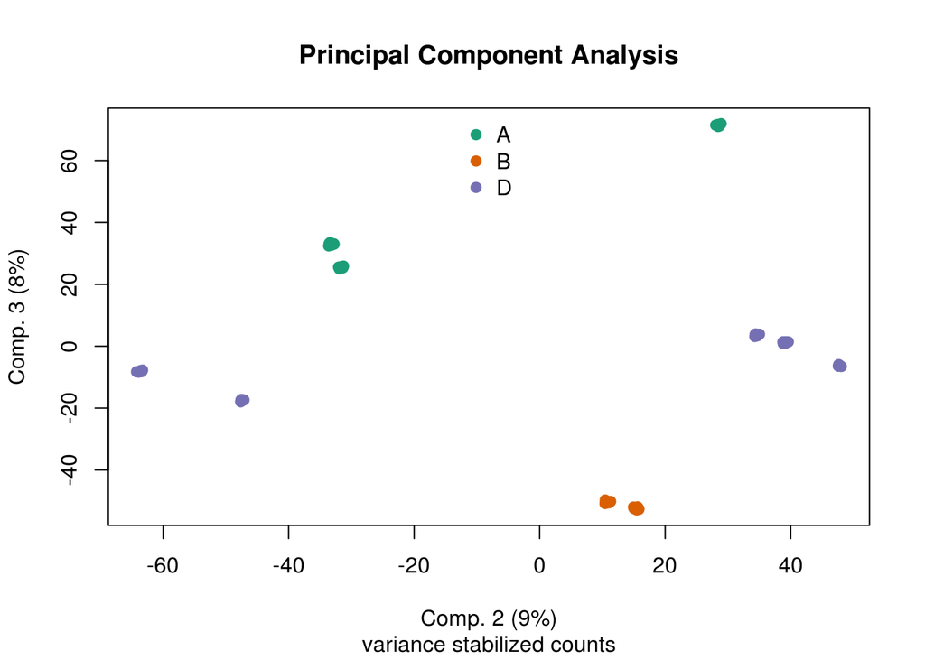

```r
plot(pc$x[,2],
     pc$x[,3],
     xlab=paste("Comp. 2 (",percent[2],"%)",sep=""),
     ylab=paste("Comp. 3 (",percent[3],"%)",sep=""),
     col=c(pal[1:3])[as.integer(factor(substr(samples$SampleDescription,1,1)))],
     pch=19,
     main="Principal Component Analysis",sub="variance stabilized counts")
legend("top",col=pal[1:3],
       legend=levels(factor(substr(samples$SampleDescription,1,1))),
       pch=19,bty="n")
```

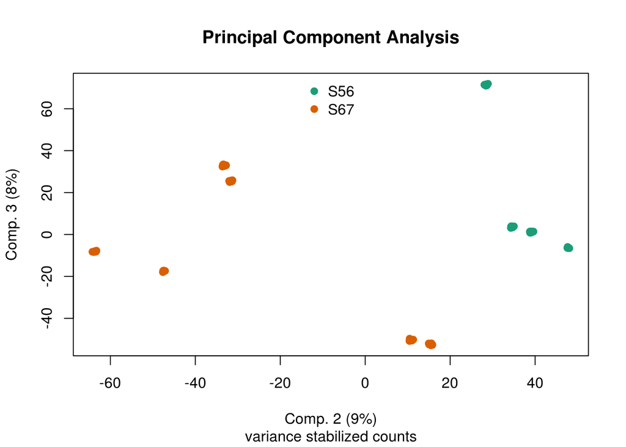

```r
plot(pc$x[,2],
     pc$x[,3],
     xlab=paste("Comp. 2 (",percent[2],"%)",sep=""),
     ylab=paste("Comp. 3 (",percent[3],"%)",sep=""),
     col=c(pal[1:2])[as.integer(factor(substr(samples$SampleDescription,3,5)))],
     pch=19,
     main="Principal Component Analysis",sub="variance stabilized counts")
legend("top",col=pal[1:2],
       legend=levels(factor(substr(samples$SampleDescription,3,5))),
       pch=19,bty="n")
```

## 3.2 Heatmap

The 1000 most variable genes are selected and plotted as a heatmap

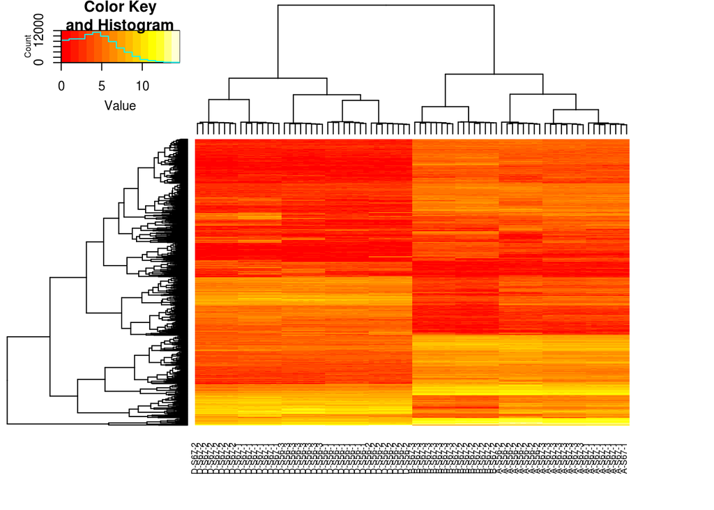

```r
dimnames(vst) <- dimnames(count.table)
sel <- order(apply(vst,1,sd),decreasing=TRUE)[1:1000]
heatmap.2(vst[sel,],labRow = NA,trace = "none",cexCol = 0.6,
          labCol =  samples$SampleDescription)
```

The distinction between Dark and Light treated (A & B) is very clear in these 1000 first genes.

# 4 Conclusion

The raw quality of the data appears very good. The data normalisation gives satisfying results (as far as the VST fit is concerned). The PCA and the heatmap identifies no samples as possible outliers. Moreover, it is clear from the analysis that the technical replicates can be combined together, which is what we do next

```r
count.table <- do.call(cbind,lapply(split.data.frame(t(count.table),samples$SampleName),colSums))
colnames(count.table) <- samples$SampleDescription[match(colnames(count.table),samples$SampleName)]
count.table <- count.table[,order(colnames(count.table))]
write.csv(count.table,"analysis/HTSeq/raw-unormalised_tech-rep-combined_data.csv")
```